# EDA Assignment 2

Yerin Jung

06/01/2018

# 1 Lead

For this assignment, I followed three steps:

1. Sampling:
- I am going to use systematic sampling, since the files are stored in chronological order.
2. Feature Engineering:
- I am going to make possibly useful features and examine each feature.
3. Matrices Examination:
- Using the features that I have created in section 2, I am going to examine some matrices.

# 2 EDA

Below chunks are to set up data and required functions.

```r
setwd("/Users/Jung-yerin/Desktop/SUMMER_2018/AD/Week2")
source("telemetry-functions.R")
sourceDir <- file.path("sourceData", "FEATURES-2014-2015")
filenames <- list.files(sourceDir, full.names=TRUE)
library(RcppRoll)
```

```r
# this file is used to translate original names and shortened names
ss <- read_csv("features-schema-descriptions.csv")
# need to still fix the names to be more R friendly
new_names <- cleanNames(ss$short_name)
```

## 2.1 Sampling Data

I am going to use $Systematic$ $Sampling$ method for sampling, since the population is presented in chronological order.  
To do so, I made a function to conduct systematic sampling.

```r
# A function to do systematic sampling
sys_sampling = function(N,n){
  k = ceiling(N/n)
  r = sample(1:k, 1)
  sys_samp = seq(r, r + k*(n-1), k)
  cat("The selected systematic samples are: \"", sys_samp, "\"\n")
  return(filenames[sys_samp])
}

set.seed(1993)
sample(filenames,3)
```

```
## [1] "sourceData/FEATURES-2014-2015/part-061.csv"
## [2] "sourceData/FEATURES-2014-2015/part-004.csv"
## [3] "sourceData/FEATURES-2014-2015/part-069.csv"
```

```r
fileList <-sys_sampling(length(filenames),10)
```

```
## The selected systematic samples are: " 15 35 55 75 95 115 135 155 175 195 "
```

```r
telemetryDF <- loadTelemetryFiles(fileList, new_names)
```

```
## [1] "Loading: sourceData/FEATURES-2014-2015/part-014.csv ..."
## [1] "Done"
## [1] "Loading: sourceData/FEATURES-2014-2015/part-034.csv ..."
## [1] "Done"
## [1] "Loading: sourceData/FEATURES-2014-2015/part-054.csv ..."
## [1] "Done"
## [1] "Loading: sourceData/FEATURES-2014-2015/part-074.csv ..."
## [1] "Done"
## [1] "Loading: sourceData/FEATURES-2014-2015/part-094.csv ..."
## [1] "Done"
## [1] "Loading: sourceData/FEATURES-2014-2015/part-114.csv ..."
## [1] "Done"
## [1] "Loading: sourceData/FEATURES-2014-2015/part-134.csv ..."
## [1] "Done"
## [1] "Loading: sourceData/FEATURES-2014-2015/part-154.csv ..."
## [1] "Done"
## [1] "Loading: sourceData/FEATURES-2014-2015/part-174.csv ..."
## [1] "Done"
## [1] "Loading: sourceData/FEATURES-2014-2015/part-194.csv ..."
## [1] "Done"
```

```r
print( sprintf("Sampled %d/%d files", length(fileList), length(filenames)) )
```

```
## [1] "Sampled 10/200 files"
```

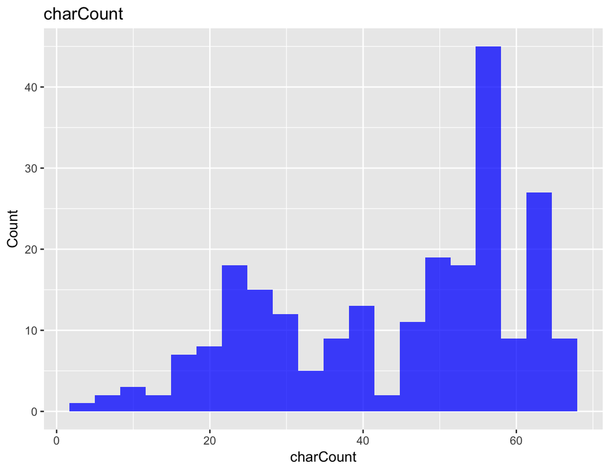

```r
plotCharLengthDistribution(names(telemetryDF), nBins = 20)
```

## 2.2 Feature Engineering

### 2.2.1 Dataframe Exploration

Before creating features, I will explore the data.frame as follows.

```r
class(telemetryDF)
```

```
## [1] "data.frame"
```

```r
nrow(telemetryDF)
```

```
## [1] 379427
```

```r
# identifier columns
idCols <-  c('host', 'process', 'timestamp', 'isAnomaly', 'No_data')

# get the column names
colNames <- names(telemetryDF)

# these are identifiers and not telemetry metrics
metricNames <- sort( colNames[! colNames %in% idCols] )

# For anomaly detection or any modeling, we can remove those with NO change in value
gatheredDF <- gather(telemetryDF %>% select(metricNames), "metric", "value" )

head(gatheredDF)
```

```
##                                                  metric value
## 1 Active_connections_source01_JDBCConnectionPoolRuntime     0
## 2 Active_connections_source01_JDBCConnectionPoolRuntime     0
## 3 Active_connections_source01_JDBCConnectionPoolRuntime     0
## 4 Active_connections_source01_JDBCConnectionPoolRuntime     0
## 5 Active_connections_source01_JDBCConnectionPoolRuntime     0
## 6 Active_connections_source01_JDBCConnectionPoolRuntime     0
```

```r
nrow(gatheredDF)
```

```
## [1] 87268210
```

```r
metricDF <- gatheredDF %>%
  group_by(metric) %>%
  summarise(
    count = n(),
    mean = mean(value),
    med = median(value),
    sd = sd(value),
    min = min(value),
    max = max(value),
    Q1 = quantile(value, probs=.25, na.rm=TRUE),
    Q3 = quantile(value, probs=.75, na.rm=TRUE)
  )
usefulMetrics <- metricDF %>% filter( min != max )
nrow(usefulMetrics)
```

```
## [1] 156
```

```r
# filter down to used metrics
useCols <- c( idCols, unique(usefulMetrics$metric))

telemetryDF2 <- telemetryDF %>% filter( No_data == 0 ) %>% select(useCols)
```

### 2.2.2 Creating Features

Now, I am going to create features.

```r
# First, we need to create a timestamp column
telemetryDF2$TS <- as.POSIXct( strptime(telemetryDF2$timestamp, "%Y-%m-%d %H:%M") )

telemetryDF2$Month <- as.numeric( strftime(telemetryDF2$TS, "%m"))
telemetryDF2$Date <- as.Date( strftime(telemetryDF2$TS, "%Y-%m-%d") )
telemetryDF2$Hour <- as.numeric( strftime(telemetryDF2$TS, "%H") )
telemetryDF2$Minute <- as.numeric( strftime(telemetryDF2$TS, "%M") )
telemetryDF2$Weekday <- as.factor(strftime(telemetryDF2$TS, "%A"))
telemetryDF2 <- telemetryDF2 %>%
  mutate(Biz_Hour=as.factor(ifelse( !Weekday %in% c("Saturday","Sunday") &  telemetryDF2$Hour >=9 & telemetryDF2$Hour <=17, 1,0)))
telemetryDF2$Weekend <- as.factor(ifelse(telemetryDF2$Weekday=='Saturday' |telemetryDF2$Weekday=='Sunday',1,0))

telemetryDF2 <-
  telemetryDF2 %>% mutate(Biz_Quarter=(cut(Month, breaks = 4, labels = c("Q1","Q2","Q3","Q4"))) )
telemetryDF2 <-
  telemetryDF2 %>% mutate(rolling_window = cut(TS, '30 min'))
```

I created `TS`, `Month`, `Date`, `Hour` and `Minute` just as we did during the class.  
In addition, I made `Weekday`, `Weekend`, `Biz_Hour`, `Biz_Quarter`, and `rolling_window` to detect any patterns in `isAnomaly`.

The descriptions for each variable are as follows:  
- `Weekday` : Day of Week  
- `Weekend` : 1 if a value of `Weekday` is weekend (Saturday or Sunday), 0 if not  
- `Biz_Hour` : 1 if a value of `Hour` is during the business hours (9 am to 5 pm), 0 if not  
- `Biz_Quarter` : `<Q1>` Jan, Feb, Mar `<Q2>` Apr, May, Jun `<Q3>` Jul, Aug, Sep `<Q4>` Oct, Nov, Dec  
- `rolling_window` : A time window every 30 minutes